# Gender Pay Gap: `ggplot` workshop

Neil Stewart

```r
library(tidyverse)
library(lubridate)
options(width=100)
```

# Week 3 Workshop: Part 1

In Part 1 of this workshop we will draw `ggplot()`s plots of the gender pay gap data

Be sure to produce *production ready* plots, complete with *figure captions*

## Tasks for today

1. Draw a histogram of the variable `DiffMeanHourlyPercent`. Don’t forget to consider a sensible bin width. What is a sensible scale for the x-axis?
2. Are public sector employers better than businesses or charities? Plot the distribution of `DiffMeanHourlyPercent` for each type of employer. Add vertical lines to highlight the means of the distribution (Hint: `geom_vline()`)
3. Is the pay gap worse for employers submitting late? Draw histograms for `DiffMeanHourlyPercent` for on-time and late submissions. Add smoothed density plots to help the comparison. Finally, give up on this and draw empirical cumulative density functions (hint: `stat_ecdf()`). What can you learn from comparing the cumulative density functions that it is hard to see in the other plots

Finally, check you can knit your Rmarkdown document to produce an HTML file documenting everything you have done

## Learning objectives for today

1. Practice using `ggplot`
2. Learn how to make production-ready plots with labels and captions
3. Understand why some plots are better at conveying patterns in the data than others

```r
pay.gap <- read_csv("UK_gender_pay_gap_2017-18.csv")
```

# Histogram of `DiffMeanHourlyPercent`

```r
filter(pay.gap, abs(DiffMeanHourlyPercent)>100)
```

```
## # A tibble: 6 x 25
##   EmployerName  Address   CompanyNumber SicCodes DiffMeanHourlyP… DiffMedianHourl… DiffMeanBonusPe…
##   <chr>         <chr>     <chr>         <chr>               <dbl>            <dbl>            <dbl>
## 1 BAR 2010 LIM… "Mitre H… 04172269      70229               -148.          -196.                 0.
## 2 BARLOWS (U.K… "Cliffor… 02857344      43210               -268.            22.9              -60.
## 3 COMPLETE CAR… "1310 So… 04522416      86900               -400.           -11.0              100.
## 4 INBRELLA LIM… "5th, Fl… 08274708      69201               -150.          -164.                 0.
## 5 MILLWALL HOL… "The Den… 02355508      "93110,…             159.             0.                99.
## 6 Solent Acade… "Mary Ro… 08374351      "1,\r\n…            -107.            -3.00               0.
## # ... with 18 more variables: DiffMedianBonusPercent <dbl>, MaleBonusPercent <dbl>,
## #   FemaleBonusPercent <dbl>, MaleLowerQuartile <dbl>, FemaleLowerQuartile <dbl>,
## #   MaleLowerMiddleQuartile <dbl>, FemaleLowerMiddleQuartile <dbl>, MaleUpperMiddleQuartile <dbl>,
## #   FemaleUpperMiddleQuartile <dbl>, MaleTopQuartile <dbl>, FemaleTopQuartile <dbl>,
## #   CompanyLinkToGPGInfo <chr>, ResponsiblePerson <chr>, EmployerSize <chr>, CurrentName <chr>,
## #   SubmittedAfterTheDeadline <chr>, DueDate <chr>, DateSubmitted <chr>
```

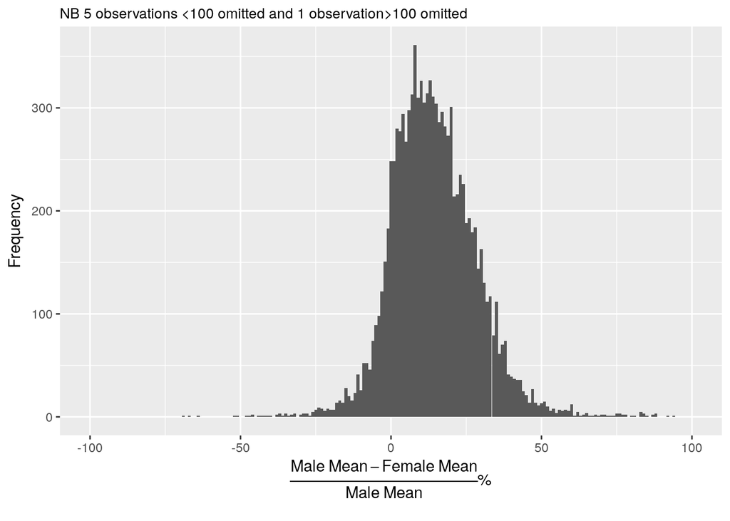

```r
ggplot(pay.gap, aes(x=DiffMeanHourlyPercent)) + geom_histogram(binwidth=1) + xlim(-100, 100) + labs(x=expression(frac(Male~Mean-Female~Mean,Male~Mean)*'%'), y="Frequency", subtitle="NB 5 observations <100 omitted and 1 observation>100 omitted")
```

Figure X. The distribution of gender pay gap. Pay gap is defined as the difference between mean male pay and mean female pay as a fraction of mean male pay. Bars are bins 1% wide

# Are public sector employers better than businesses or charities?

```r
pay.gap <- mutate(pay.gap, DueDate=dmy_hms(DueDate), Sector=ifelse(DueDate==ymd("2018-03-31"), "Public Sector", "Business / Charity"))

(  pay.gap.by.sector <- pay.gap %>% group_by(Sector) %>% summarise(frequency=n(), mean=mean(DiffMeanHourlyPercent))  )
```

```
## # A tibble: 2 x 3
##   Sector             frequency  mean
##   <chr>                  <int> <dbl>
## 1 Business / Charity      8850  14.2
## 2 Public Sector           1682  14.9
```

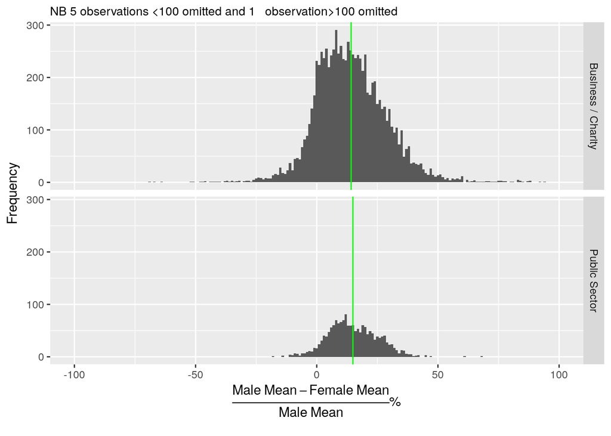

```r
ggplot(pay.gap) + geom_histogram(aes(x=DiffMeanHourlyPercent), binwidth=1) + facet_grid(Sector~.) + xlim(-100,100) + labs(x=expression(frac(Male~Mean-Female~Mean,Male~Mean)*'%'), y="Frequency", subtitle="NB 5 observations <100 omitted and 1   observation>100 omitted") + geom_vline(data=pay.gap.by.sector, mapping=aes(xintercept=mean), col="green")
```

Figure X. The distribution of gender pay gap by industry sector. Green lines mark distribution means

# Does submitting late predict pay gap?

```r
pay.gap <- pay.gap %>% mutate(SubmittedAfterTheDeadline=factor(SubmittedAfterTheDeadline, levels=c("True", "False"), labels=c("Late Submissions", "On-Time Submissions")))

pay.gap %>% group_by(SubmittedAfterTheDeadline) %>% summarise(frequency=n(), mean=mean(DiffMeanHourlyPercent))
```

```
## # A tibble: 2 x 3
##   SubmittedAfterTheDeadline frequency  mean
##   <fct>                         <int> <dbl>
## 1 Late Submissions                641  11.2
## 2 On-Time Submissions            9891  14.5
```

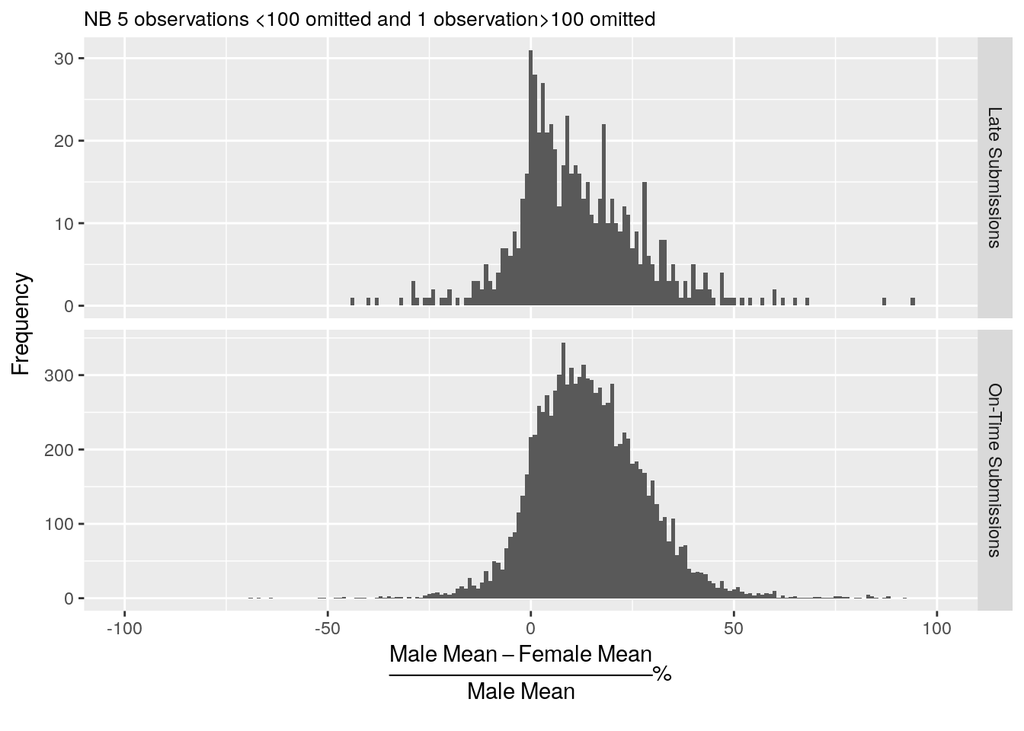

```r
ggplot(pay.gap, aes(x=DiffMeanHourlyPercent)) + geom_histogram(binwidth=1) + facet_grid(SubmittedAfterTheDeadline~., scales="free_y") + xlim(-100,100) + labs(x=expression(frac(Male~Mean-Female~Mean,Male~Mean)*'%'), y="Frequency", subtitle="NB 5 observations <100 omitted and 1 observation>100 omitted")
```

Figure X. The distribution of gender pay gap by submission time. Note the change in frequency scale between panels

It is hard to see the difference in the distributions, so let’s try augmenting the distributions with density plots

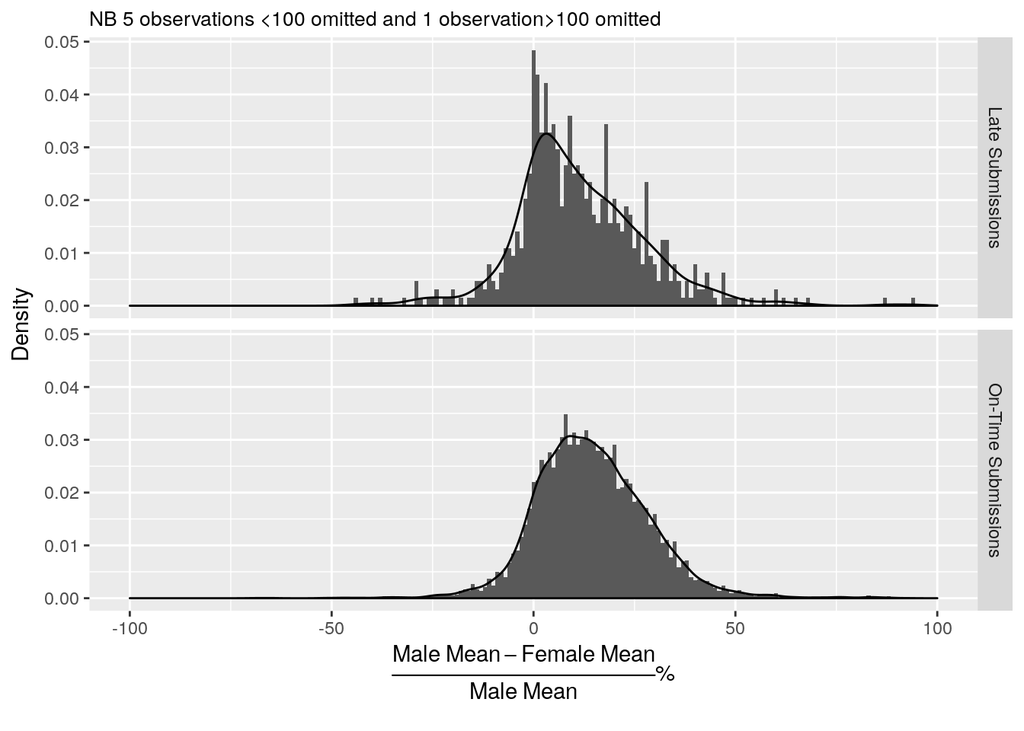

```r
ggplot(pay.gap, aes(x=DiffMeanHourlyPercent, y=..density..)) + geom_histogram(binwidth=1) + facet_grid(SubmittedAfterTheDeadline~.) + xlim(-100,100) + labs(x=expression(frac(Male~Mean-Female~Mean,Male~Mean)*'%'), y="Density", subtitle="NB 5 observations <100 omitted and 1 observation>100 omitted") + geom_density()
```

Figure X. The distribution of gender pay gap by submission time. Bars show the density in 1% bins, and the black line shows the Gaussian smoothed density using Silverman’s rule of thumb

See `?geom_density`, which leads you to `?bw.nrd` to find out how `geom_density()` does the smoothing

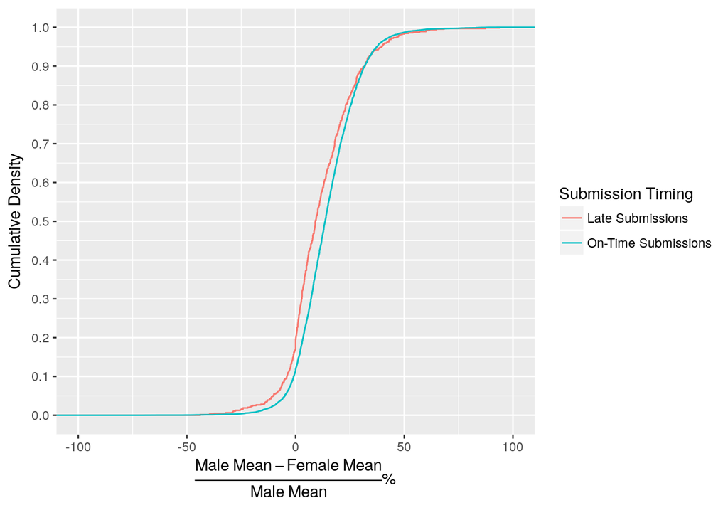

```r
ggplot(pay.gap, aes(x=DiffMeanHourlyPercent, col=SubmittedAfterTheDeadline)) + stat_ecdf() + xlim(-100,100) + labs(x=expression(frac(Male~Mean-Female~Mean,Male~Mean)*'%'), y="Cumulative Density", col="Submission Timing") + scale_y_continuous(breaks=seq(0,1,0.1))
```

Figure X. The empirical cumulative density function for the gender pay gap, separated by submission timing

The distribution for late submissions is almost always to the left of the distribution for the on-time submissions, which means that the gender pay gap is a little smaller. However the CDFs cross just above the 90th percentile, which means the late submissions have the longer tail.